# Práctica Grupal

Mario Muñoz Mesa, Irene Pérez Martínez, Carlota Valdivia Manzano.

24-05-2022

## Discusión sobre los valores perdidos

### Qué son los datos perdidos y pasos a seguir para solucionar su problema

Los datos perdidos son valores no tomados en una muestra de datos observados. Esto puede deberse a diversos motivos: el campo no estaba permitido, el dato no estaba permitido, no sé tomó correctamente la información de la muestra… Debido a esto podemos realizar una clasificación en cuanto al tipo de dato perdido que posee un dataset, y determinar a partir de ahí cómo trabajar los datos o si será necesario realizar un trabajo extra.

El problema de los datos perdidos es que pueden suponer la no comprensión correcta de los datos sí observados y dar lugar a conclusiones erróneas. Para evitar esto, en aquellos casos donde sea necesario, se realiza una labor de imputación: generar datos que sustituyan a aquellos que se encuentran vacíos. Existen diversos métodos para realizar esta operación, algunos de los cuales vamos a mencionar o mostrar en ejemplo.

### Tipos de datos perdidos

Podemos, y debemos, clasificar los distintos tipos de datos perdidos que podemos encontrar, pues estos afectan al enfoque con el que enfrentarnos al problema de imputarlos. Para concluir que los datos perdidos son de un tipo concreto es recomendable observar el comportamiento de los mismos. Podemos distinguir a nivel general, siguiendo lo que estipulan la mayoría de profesionales que trabajan el tema, los siguientes tipos.

#### MCAR o Missing Completely At Random (perdidos completamente)

Se consideran de este bloque aquellos datos perdidos que cumplen que no existe ningún patrón que los relacione con los datos sí almacenados o las propias variables. Es decir, se trata de aquellos datos que están perdidos de forma completa y totalmente aleatoria. No hay ninguna acción sistemática que influya en que aparezca perdido un tipo de dato más que otro.

Son un tipo de dato más factible de manejar, ya que aunque reduce el poder de las conclusiones por haber menor cantidad de información se continúa obteniendo resultados correctos. Es bastante improbable que los datos perdidos de una observación sean de este tipo, aunque sería lo deseable.

#### MAR o Missing At Random (perdidos)

Son aquellos casos en los que la falta de esos datos perdidos tiene relación con las variables del dataset. En aquellos casos que tengan este tipo de datos perdidos se puede observar una relación entre los datos observados y las variables, aunque no con respecto a los datos perdidos en sí. Es decir, se aprecia un patrón que asocia la falta de datos de una variable con uno o varios datos observados.

Por ejemplo, si las mujeres sí suelen responder a preguntas sobre sus emociones mientras que los hombres no, aparecerán muchos más datos no observados o perdidos asociados a los hombres en ese campo. En este caso el dato observado que afecta sería el sexo de la persona cuestionada.

#### MNAR o Missing Not At Random (perdidos no aleatorios)

Son aquellos datos perdidos de los que podemos determinar que aunque están perdidos su falta no es aleatoria. Podremos encontrar en estos casos patrones que relacionen las pérdidas con las otras variables del dataset.

Imaginemos por ejemplo que cada vez que ingresan a un paciente en un hospital se toman una serie de datos sobre él. En el caso de los ingresados por una emergencia no se registra si fuma o no tabaco. Ese tipo de dato perdido es un ejemplo del que estamos tratando.

Son casos importantes que pueden alterar gravemente las conclusiones que se extraigan del dataset y que dificultan enormemente el diagnóstico, haciéndose inmanejable.

### Pasos para el procesamiento correcto de los datos perdidos

1. Asegurar que los datos están codificados adecuadamente. Aunque puede parecer obvio, gran parte de las veces se pasa por alto este paso y puede dar lugar a muchos errores que se subsanarían fácilmente. Una opción es el uso de paquetes como `finalfit`, que se asegura de que los factores y números están asignados correctamente, además de indicar qué variables tienen datos perdidos.
2. Identificar los valores perdidos en cada variable. Para realizar esto lo recomendable es poder hacer una representación de todos los datos para evaluar gráficamente. Una opción recomendable es el uso de la función `missing_plot`.
3. Realizar una inspección de los posibles patrones que presentan los datos perdidos. Una opción es el uso de funciones como `missing_pattern`.
4. Revisar posibles asociaciones entre los datos perdidos y los observados. En este paso se determina el tipo de dato perdido que tenemos, y se explicará más adelante con mayor profundidad cómo podemos realizar esta tarea.
5. Una vez determinado el tipo de dato perdido y el grado de efecto que produce, determinar cómo manejar la situación. En este punto hay que decidir si se quiere o no realizar una imputación en los datos perdidos, y si es así, elegir el mejor método de acuerdo con nuestros datos. Veremos de forma breve algunos métodos y de forma más extensa la resolución usando los paquetes MICE, Amelia y missForest.

### Ejemplo de identificación de los valores perdidos

Como comentábamos antes, esto puede realizando mediante el uso de la función `missing_plot`, que genera una gráfica donde se agrupan en el eje y todas las variables. Un ejemplo de uso sería el siguiente:

```r
install.packages("finalfit")
install.packages("dplyr")
library(dplyr)
```

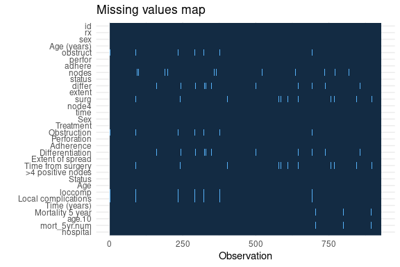

```r
library(finalfit)
colon_s %>%
  missing_plot()
```

### Ejmplo de búsqueda de patrones

Como se menciona previamente es posible hacer uso de funciones como missing_pattern que faciliten la búsqueda de patrones en los datos observados y perdidos. Un ejemplo de uso sería el que se muestra a continuación:

[figure not shown]

[output not shown]

```r
explanatory = c("age", "sex.factor",
  "obstruct.factor",
  "smoking_mcar", "smoking_mar")
dependent = "mort_5yr"

colon_s %>% missing_pattern(dependent, explanatory)
```

### Determinar el tipo de dato perdido

Una manera de determinar si los datos perdidos son del tipo MCAR o del tipo MAR es mediante la exploración en busca de patrones de pérdida en los diversos valores que poseen las variables. Para poder observarlos podemos hacer uso de `missing_pairs`, que utiliza funciones del paquete GGally, produciendo gráficas que muestran la relación entre los datos perdidos y los valores observados en todas las variables. Gracias a esto tendremos una muestra gráfica más sencilla de estudiar.

Es una función útil si contamos con datos continuos, pero también puede usarse para datos discretos comparando proporciones.

### Discusión sobre la ignorabilidad de los datos perdidos

Los datos perdidos pueden llegar a afectar enormemente al trabajo y las conclusiones que extraigamos de los sí observados. Así pues, es importante en primer lugar determinar si los datos faltantes son o no cruciales, ya que si concluimos que pueden ser obviados evitaríamos los pasos que se muestran en los siguientes apartados, es decir, no tendríamos que imputar unos datos para rellenar aquellos vacíos.

Los datos perdidos clasificados como MAR pueden ser ignorados a la hora de sacar conclusiones. Por otro lado, aunque resulta bastante obvio, si los parámetros que queremos trabajar o que son de nuestro interés no tienen relación con los datos perdidos que presenta nuestro dataset tampoco sería necesario realizar una labor de imputación.

En cambio, aquellos datos perdidos calificados como MNAR no pueden ser ignorados porque supondría grandes fallos en las conclusiones que se tomen sobre los datos observados.

También hay que tener en cuenta que, aunque algunos tipos de datos perdidos podrían ser ignorados, eso no significa que no se pueda realizar una imputación sobre ellos. El caso es establecer un equilibrio entre la validez de nuestras conclusiones y la dificultad que puede suponer generar datos adecuados para los valores perdidos del dataset.

### Solución a los datos perdidos

#### Eliminación

La primera manera de gestionar los datos perdidos es simplemente eliminarlos de las observaciones. Contamos con dos tipos de eliminación:

- **Listwise Deletion**: también llamado eliminación por lista, consiste en eliminar las observaciones que presentan perdidas todas sus variables. Elimina todos los datos de un caso que tiene uno o más valores faltantes. Puede ser aplicado a cualquier test, y funciona bien con datos tipo MCAR, pero podemos alcanzar una cota de error más alta y no se recomienda con datos tipo MAR. El mayor problema es que tras aplicar este método terminamos trabajando con una muestra sesgada que puede tener consecuencias en las conclusiones.
- **Pairwise Deletion**: denominado también eliminación por pares,determinamos los estimadores del coeficiente y se realiza un proceso de regresión. Es un método con menos consecuencias negativas comparado con la eliminación por listas, pues no se omiten los casos por completo de los análisis. En concreto, omite casos en función de las variables incluídas en el análisis. Un defecto es que solo puede ser usado en caso de modelos lineales.

Por supuesto esta acción viene de la mano de si los datos son o no ignorables, como comentábamos en el apartado anterior.

#### Imputación

La imputación es un método que busca rellenar los huecos vacíos de las observaciones. El objetivo es determinar los nuevos valores de manera que tengan sentido con respecto a los datos que sí poseemos para que estos no generen conclusiones equivocadas.

Las opciones más frecuentemente usadas son la media y la mediana, si el atributo es cuantitativo, y la moda, si es cualitativo. Podemos hacer uso de dos maneras de aplicar la imputación:

1. **Imputación Generalizada**: se calcula la media o mediana de todos los valores observados de la variable que presenta datos perdidos. Se establece ese valor en los vacíos.
2. **Imputación por caso similar**: se hace una agrupación y se determina el valor de los datos perdidos en función de otras variables que están en juego y su valor. Establecemos una relación en función de lo que se ha observado.

A pesar de ser uno de los métodos más utilizados, presenta algunas desventajas importantes, ya que no preserva relaciones entre las variables, y puede provocar que se cometan errores tipo 1.

Otro método de imputación a destacar es la **imputación KNN**. En él, el valor de un atributo que falte se determina en función de la similitud entre el resto de atributos que tiene la observación con las demás observaciones de la muestra. Se compara mediante una función de similitud las distintas observaciones y en función de aquellas que se consideren “cercanas” a la que estamos intentado imputar se determina el valor que tendrá. Como ventajas destacar que se puede usar tanto en casos cualitativos como en cuantitativos, que no requiere un modelo predictivo para cada atributo y que permite tratar fácilmente atributos que presenten múltiples datos perdidos. En contra destaca la carga de tiempo que consume analizar datasets de gran tamaño y que puede ser compleja la elección de la función de distancias, pues los resultados pueden variar en función de la distancia que permitamos.

Otra opción es usar un **modelo predictivo**, que se considera uno de los métodos más sofisticados en el manejo de los datos perdidos. Consiste en crear un modelo predictivo para estimar valores que sustituirán posteriormente a los datos no tomados. El sistema es dividir el dataset en dos partes: una sin datos perdidos y otra con. La primera se transforma en un dataset de entrenamiento con el que iremos generando datos, que se probarán y terminarán rellenando los datos vacíos en el segundo grupo. Un ejemplo el missForest, que mencionamos ampliamente más adelante.

## MICE

MICE (Multivariate Imputation via Chained Equations) es un tipo particular de imputación múltiple bastante popular, puede imputar variables continuas y categóricas. Está diseñado para caso de datos perdidos tipo MAR, es decir, la probabilidad de que una variable presente valor perdido depende de las variables sí observadas y no de la variable que presenta el valor perdido (es el tipo más asumible en casos reales).

Muchos de los métodos de imputación múltiple iniciales asumían distribuciones multivariantes, como distribución normal multivariante. Sin embargo en grandes conjuntos de datos, con cientos de variables de distinto tipo, esto raramente es apropiado. MICE es una alternativa flexible a estos modelos de distribuciones conjuntas. En MICE, se usa una cadena de ecuaciones de regresión para obtener las imputaciones, esto es, las variables con datos faltantes son imputadas una a una en base al resto de variables del modelo, y pudiendo además ser imputada cada variable en base a su tipo (para variables binarias puede usarse regresión logística, y para continuas regresión lineal).

El proceso de ecuaciones encadenadas de MICE puede dividirse en 6 pasos:

1. Se realiza una imputación simple, como podría ser reemplazar por la media, para cada valor faltante en el dataset.
2. Se toma una variable, $v$, y los datos imputados que inicialmente eran faltantes para $v$ se marcan como faltantes.
3. Los valores observados (no faltantes) para la variable $v$ del paso 2 son utilizados para construir un modelo de regresión en base al resto de variables.
4. Los valores faltantes para $v$ son entonces reemplazados por predicciones del modelo de regresión construido. Cuando $v$ sea usado como variable para construir un modelo de regresión para otra variable se utilizarán todos los datos; los datos observados y los imputados.
5. Los pasos 2-4 son repetidos para cada variable que tenga datos perdidos. A cada recorrido de las variables se le conoce como ciclo o iteración. Al final de cada iteración todos los datos perdidos han sido reemplazados con predicciones en base al resto de variables.
6. Los pasos 2-4 son repetidos un número de ciclos o iteraciones.

El número de iteraciones a realizar se especifica como parámetro, normalmente 10 iteraciones son suficientes, sin embargo podría requerirse más, la idea es que al final de las iteraciones los parámetros de los modelos de imputación, por ejemplo los coeficientes de regresión, se estabilicen.

El esquema general en MICE y otros métodos de imputación múltiple pasa por repetir el proceso anterior generando varios datasets, los valores que diferirán entre los datasets son los que originalmente eran faltantes. Normalmente 5-10 datasets suelen ser suficientes. Después de esta fase viene una fase de análisis donde se pueden generar modelos predicitivos, y una fase de “pooling” donde se combinan los resultados (Rubin, 1987) de los distintos análisis.

Mostramos un gráfico descriptivo de estos pasos con las funciones y tipos de datos asociados en el paquete `mice`

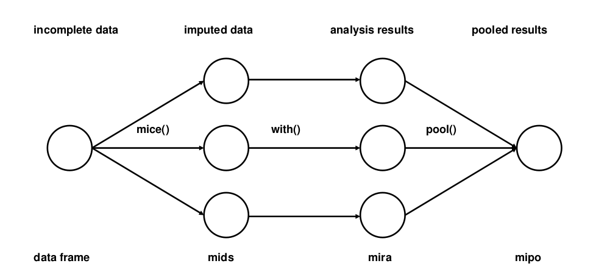

Esquema MICE en base a paquete `mice`

### Aplicación práctica

Mostramos ahora un par de ejemplos de aplicación

```r
install.packages("mice")
suppressPackageStartupMessages(library(mice))
library("mice")
```

#### `nhanes2`

El paquete `mice` proporciona algunos datasets. Por ejemplo `nhanes2` es un pequeño dataset, 25 observaciones, que contiene variables numéricas y categóricas. Recoge 4 variables:

- **age** Grupo de edad (20-39, 40-59, 60+)
- **bmi** Índice de de masa corporal ($\frac{kg}{m^2}$)
- **hyp** Si la persona es hipertensa (1=no, 2=sí)
- **chl** Colesterol ($\frac{mg}{dL}$)

```r
data(nhanes2)
summary(nhanes2)
```

```
##     age          bmi          hyp          chl
##  20-39:12   Min.   :20.40   no  :13   Min.   :113.0
##  40-59: 7   1st Qu.:22.65   yes : 4   1st Qu.:185.0
##  60-99: 6   Median :26.75   NA's: 8   Median :187.0
##             Mean   :26.56             Mean   :191.4
##             3rd Qu.:28.93             3rd Qu.:212.0
##             Max.   :35.30             Max.   :284.0
##             NA's   :9                 NA's   :10
```

En age no tenemos valores perdidos.

```r
nhanes2.imp = mice(nhanes2, m=5, maxit=10, defaultMethod=c("cart", "logreg"), seed = 1)
```

```
##
...
```

Ahora tenemos 5 datasets completos, podemos acceder a cualquiera de ellos con la función `complete`

```r
complete(nhanes2.imp, 1) # primer dataset
```

```
##      age  bmi hyp chl
## 1  20-39 22.5  no 118
## 2  40-59 22.7  no 187
## 3  20-39 26.3  no 187
## 4  60-99 22.7  no 206
## 5  20-39 20.4  no 113
## 6  60-99 21.7  no 184
## 7  20-39 22.5  no 118
## 8  20-39 30.1  no 187
## 9  40-59 22.0  no 238
...
```

Supongamos que se tiene como interés realizar una regresión lineal de `chl` en base a `age` y `bmi`. Para esto podemos usar la función `with` que permitirá aplicar el modelo de regresión a cada uno de los datasets. (fase de análisis)

```r
fit <- with(nhanes2.imp, lm(chl ~ age + bmi))
```

Para realizar el pooling basta llamar a la función `pool`

```r
fit.p<-pool(fit)
summary(fit.p)
```

```
##          term  estimate std.error statistic       df    p.value
## 1 (Intercept) 34.083379 72.997083 0.4669143 8.012347 0.65299487
## 2    age40-59 38.026253 27.367775 1.3894536 5.337754 0.21987145
## 3    age60-99 54.806964 25.305200 2.1658380 8.915556 0.05878904
## 4         bmi  5.216525  2.618266 1.9923584 7.822600 0.08228652
```

#### `airquality`

Para un segundo ejemplo imputaremos en base a las variables `Ozone`, `Solar.R`, `Wind` `Temp` y `Month` del conocido dataset `airquality`

```r
air <- airquality
str(air)
```

```
## 'data.frame':    153 obs. of  6 variables:
##  $ Ozone  : int  41 36 12 18 NA 28 23 19 8 NA ...
##  $ Solar.R: int  190 118 149 313 NA NA 299 99 19 194 ...
##  $ Wind   : num  7.4 8 12.6 11.5 14.3 14.9 8.6 13.8 20.1 8.6 ...
##  $ Temp   : int  67 72 74 62 56 66 65 59 61 69 ...
##  $ Month  : int  5 5 5 5 5 5 5 5 5 5 ...
##  $ Day    : int  1 2 3 4 5 6 7 8 9 10 ...
```

Es un dataset de 153 observaciones. Transformaremos `Month` a factor para que `mice` lo reconozca y trate como tal.

```r
Month_f<-factor(air$Month, labels=month.name[5:9])
air<-transform(air, Month=Month_f)
```

Vemos que tenemos datos perdidos para `Ozone` y `Solar.R`, muy pocos para `Solar.R`, menos del 5% (podrían descartarse, igualmente los imputaremos).

```r
summary(air)
```

```
##      Ozone           Solar.R           Wind             Temp
##  Min.   :  1.00   Min.   :  7.0   Min.   : 1.700   Min.   :56.00
##  1st Qu.: 18.00   1st Qu.:115.8   1st Qu.: 7.400   1st Qu.:72.00
##  Median : 31.50   Median :205.0   Median : 9.700   Median :79.00
##  Mean   : 42.13   Mean   :185.9   Mean   : 9.958   Mean   :77.88
##  3rd Qu.: 63.25   3rd Qu.:258.8   3rd Qu.:11.500   3rd Qu.:85.00
##  Max.   :168.00   Max.   :334.0   Max.   :20.700   Max.   :97.00
##  NA's   :37       NA's   :7
##        Month         Day
##  May      :31   Min.   : 1.0
##  June     :30   1st Qu.: 8.0
##  July     :31   Median :16.0
##  August   :31   Mean   :15.8
##  September:30   3rd Qu.:23.0
##                 Max.   :31.0
##
```

En `mice` se dispone de una función, `md.pattern`, bastante útil para ver la estructura de los datos faltantes

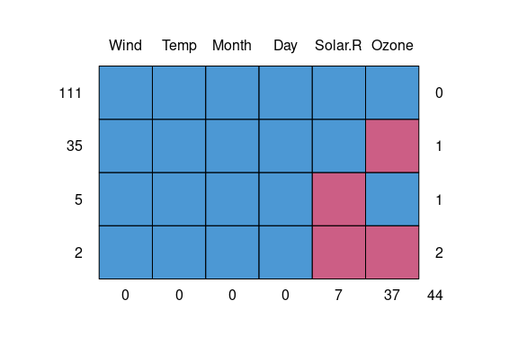

```
##     Wind Temp Month Day Solar.R Ozone
## 111    1    1     1   1       1     1  0
## 35     1    1     1   1       1     0  1
## 5      1    1     1   1       0     1  1
## 2      1    1     1   1       0     0  2
##        0    0     0   0       7    37 44
```

```r
md.pattern(air)
```

- Rojo significa dato faltante y azul no faltante
- En el eje izquierdo se muestra el número de observaciones, (por ejemplo: 111 observaciones son sin datos faltantes). En el eje derecho se cuenta el número de variables con datos faltantes (igual al número de zonas rojas).
- En eje inferior se muestra el número de datos faltantes para cada variable

Podemos indicar que no queremos que `Day` participe en la imputación en la matriz de predicciones

```r
pred.mat<-make.predictorMatrix(air)
pred.mat[,'Day']<-0
pred.mat
```

```
##         Ozone Solar.R Wind Temp Month Day
## Ozone       0       1    1    1     1   0
## Solar.R     1       0    1    1     1   0
## Wind        1       1    0    1     1   0
## Temp        1       1    1    0     1   0
## Month       1       1    1    1     0   0
## Day         1       1    1    1     1   0
```

Indicamos 40 iteraciones, `maxit=40`, y 5 imputaciones múltiples, `m=5`. Los métodos de imputación serán por defecto.

```r
air.imp <- mice(air, m=5, maxit=40, predictorMatrix = pred.mat, seed=1)
```

```
##
...
```

Podemos consultar los métodos de imputación empleados en cada variable

```r
air.imp$method
```

```
##   Ozone Solar.R    Wind    Temp   Month     Day
##   "pmm"   "pmm"      ""      ""      ""      ""
```

`mice` incluye la función `densityplot` que permite mostrar las densidades para cada uno de los datasets, separando los datos imputados de los observados:

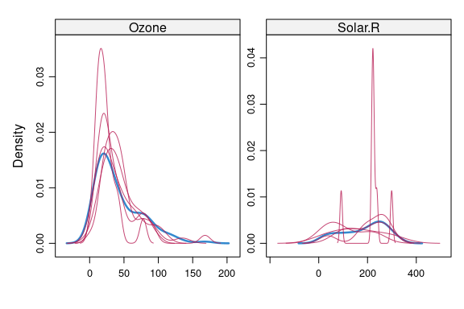

```r
densityplot(air.imp)
```

Y también proporciona proporciona una función que nos permite visualizar los datos imputados y observados en un scatter-plot unidimensional:

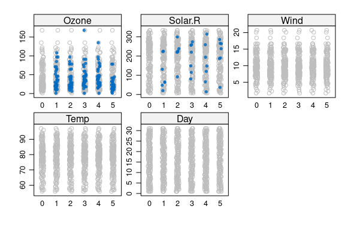

```r
stripplot(air.imp,
          col=c("grey",mdc(4)), # observados en gris
          pch=c(1,20))
```

De nuevo, podríamos construir un modelo predictivo lineal, incluyendo incluso el factor `Month` (lo tratará como categórico con One-Hot Encoding)

```r
fit2 <- with(air.imp, lm(Solar.R ~ Ozone + Temp + Wind + Month))
```

Mostramos resumen tras pooling:

```r
fit2.p<-pool(fit2)
summary(fit2.p)
```

```
##             term    estimate   std.error  statistic        df     p.value
## 1    (Intercept) -90.0387932 102.5839547 -0.8777083  54.49381 0.383955406
## 2          Ozone   0.8329119   0.3918764  2.1254454  33.36882 0.041037560
## 3           Temp   2.9834027   1.4343639  2.0799482  68.04995 0.041299398
## 4           Wind   4.8295698   2.6232130  1.8410895  48.38798 0.071743569
## 5      MonthJune -33.3338827  27.3058624 -1.2207592 129.36941 0.224397515
## 6      MonthJuly -34.1929140  29.0018834 -1.1789894 138.28867 0.240426898
## 7    MonthAugust -79.9086925  28.9837572 -2.7570163 137.15294 0.006627738
## 8 MonthSeptember -47.0249793  25.7118982 -1.8289190 131.36083 0.069679910
```

## Amelia

Amelia es un paquete que se encarga, al igual que MICE, de realizar imputación múltiple para poder tratar los datos perdidos. Amelia implementa un algoritmo denominado EMB (Expectation-Maximization with Bootstrapping) que está basado en bootstrap, por lo que normalmente es más rápido que otros y es capaz de imputar más variables. Asimismo, implementa una función de imputación paralela utilizando CPUs multinúcleo.

Es necesario hacer las siguientes dos suposiciones: que todas las variables sigan un distribución normal multivariante (MVN), utilizando medias y varianzas para resumir los datos, y que los datos perdidos sean del tipo MAR (Missing At Random).

Los pasos que sigue son:

1. Toma $m$ muestras y aplica el algoritmo EMB a cada una. Con lo cual, tenemos $m$ estimacciones de distintas medias y varianzas.
2. Después, usamos el primer conjunto de estimaciones para imputar el primer conjunto de valores perdidos mediante regresión, y por otro lado, usamos el segundo conjunto de estimaciones para el segundo conjunto de valores perdidos, y así sucesivamente.

Si realizamos una comparativa con MICE, podemos observar que:

- MICE imputa datos variable por variable, mientras que MVN utiliza un enfoque de modelado conjunto basado en una distribución normal multivariante.
- MICE puede manejar diferentes tipos de variables, mientras que en MVN deben distribuirse siguiendo una normal o transformarse para aproximarse a la normalidad.
- MICE puede gestionar la imputación de variable definifidas en un subconjunto de datos al contrario que MVN.

### Aplicación práctica

A continuación, veremos unos casos prácticos de aplicación del paquete Amelia.

En primer lugar, vamos a descargar dicho paquete.

```r
install.packages("Amelia")
library("Amelia")
```

#### `airquality`

Al igual que hemos realizado anteriormente con el paquete MICE. En este caso haremos un ejemplo práctico con Amelia sobre el dataset `airquality`.

##### Imputación

Para realizar la imputación múltiple tenemos que identificar las variables que vamos a incluir en el modelo de imputación. Debemos incluir tanta información como la que se usará en el modelo de análisis, con lo que si una variable va a estar en el modelo de anális deberá estar también en el de imputación.

Para ello, vamos a hacer uso del dataset `airquality` e imputaremos en base a las variables `Ozone`, `Solar.R`, `Wind`, `Temp`, `Month` y `Day`.

```r
air <- airquality
str(air)
```

```
## 'data.frame':    153 obs. of  6 variables:
##  $ Ozone  : int  41 36 12 18 NA 28 23 19 8 NA ...
##  $ Solar.R: int  190 118 149 313 NA NA 299 99 19 194 ...
##  $ Wind   : num  7.4 8 12.6 11.5 14.3 14.9 8.6 13.8 20.1 8.6 ...
##  $ Temp   : int  67 72 74 62 56 66 65 59 61 69 ...
##  $ Month  : int  5 5 5 5 5 5 5 5 5 5 ...
##  $ Day    : int  1 2 3 4 5 6 7 8 9 10 ...
```

Volvemos a transformar `Month` a factor para que `Amelia` lo reconozca y trate como tal.

```r
Month_f<-factor(air$Month, labels=month.name[5:9])
air<-transform(air, Month=Month_f)
```

Podemos ver un resumen estadístico de los datos para ver los que faltan en cada variable.

```r
summary(air)
```

```
##      Ozone           Solar.R           Wind             Temp
##  Min.   :  1.00   Min.   :  7.0   Min.   : 1.700   Min.   :56.00
##  1st Qu.: 18.00   1st Qu.:115.8   1st Qu.: 7.400   1st Qu.:72.00
##  Median : 31.50   Median :205.0   Median : 9.700   Median :79.00
##  Mean   : 42.13   Mean   :185.9   Mean   : 9.958   Mean   :77.88
##  3rd Qu.: 63.25   3rd Qu.:258.8   3rd Qu.:11.500   3rd Qu.:85.00
##  Max.   :168.00   Max.   :334.0   Max.   :20.700   Max.   :97.00
##  NA's   :37       NA's   :7
##        Month         Day
##  May      :31   Min.   : 1.0
##  June     :30   1st Qu.: 8.0
##  July     :31   Median :16.0
##  August   :31   Mean   :15.8
##  September:30   3rd Qu.:23.0
##                 Max.   :31.0
##
```

Amelia cuenta con un método denominado `amelia`, que se encarga de ejecutar el EMB algoritmo en datos perdidos y crea dataset imputados.

- **x** es el data.frame que vamos a usar.
- **m** indica el número de datasets imputados que vamos a crear.
- **ts** es el nombre de la variable que nos indica qué variable identifica el tiempo en los datos de la serie temporal.
- **cs** es el nombre de la variable que nos indica la variable de sección transversal.

```r
air.out <- amelia(air, m = 5, ts = "Temp", cs = "Month")
```

```
## -- Imputation 1 --
##
##   1  2  3  4  5
##
## -- Imputation 2 --
##
##   1  2  3  4
##
## -- Imputation 3 --
##
##   1  2  3  4  5  6
##
## -- Imputation 4 --
##
##   1  2  3  4  5  6
##
## -- Imputation 5 --
##
##   1  2  3  4  5  6
```

```r
air.out
```

```
##
## Amelia output with 5 imputed datasets.
## Return code:  1
## Message:  Normal EM convergence.
##
## Chain Lengths:
## --------------
## Imputation 1:  5
## Imputation 2:  4
## Imputation 3:  6
## Imputation 4:  6
## Imputation 5:  6
```

Vemos que la salida nos da información sobre cómo se ha ejecutado el algoritmo, y los datos imputados se encuentran ahora en la lista air.out$imputations.

```r
air.out$imputations[[4]]$Ozone
```

```
##   [1]  41.000000  36.000000  12.000000  18.000000  41.088747  28.000000
##   [7]  23.000000  19.000000   8.000000  23.317052   7.000000  16.000000
##  [13]  11.000000  14.000000  18.000000  14.000000  34.000000   6.000000
##  [19]  30.000000  11.000000   1.000000  11.000000   4.000000  32.000000
##  [25]   1.362535  -9.208963  36.498135  23.000000  45.000000 115.000000
##  [31]  37.000000 115.432636  65.497626  14.325077  20.693186  82.901371
##  [37]  17.168364  29.000000  51.504589  71.000000  39.000000  55.159621
##  [43]  35.141197  23.000000  48.526768   9.991065  21.000000  37.000000
##  [49]  20.000000  12.000000  13.000000  29.755242  61.002718  46.769571
##  [55]  61.455083  47.083165 102.573708  33.462116  19.416399  31.060475
##  [61]  38.069281 135.000000  49.000000  32.000000  37.859374  64.000000
##  [67]  40.000000  77.000000  97.000000  97.000000  85.000000  42.158161
##  [73]  10.000000  27.000000  42.087840   7.000000  48.000000  35.000000
##  [79]  61.000000  79.000000  63.000000  16.000000  41.541030  40.097744
##  [85]  80.000000 108.000000  20.000000  52.000000  82.000000  50.000000
##  [91]  64.000000  59.000000  39.000000   9.000000  16.000000  78.000000
##  [97]  35.000000  66.000000 122.000000  89.000000 110.000000  71.260027
## [103]  12.231021  44.000000  28.000000  65.000000  29.743120  22.000000
## [109]  59.000000  23.000000  31.000000  44.000000  21.000000   9.000000
## [115]  57.799189  45.000000 168.000000  73.000000  81.230874  76.000000
## [121] 118.000000  84.000000  85.000000  96.000000  78.000000  73.000000
## [127]  91.000000  47.000000  32.000000  20.000000  23.000000  21.000000
## [133]  24.000000  44.000000  21.000000  28.000000   9.000000  13.000000
## [139]  46.000000  18.000000  13.000000  24.000000  16.000000  13.000000
## [145]  23.000000  36.000000   7.000000  14.000000  30.000000   9.576798
## [151]  14.000000  18.000000  20.000000
```

Si queremos ver un histograma de la variable Ozone a partir de la 4º imputación.

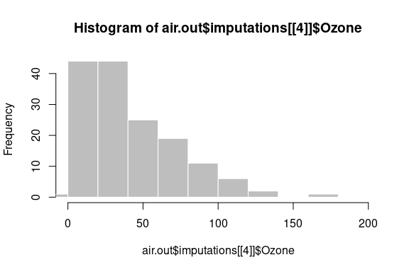

```r
hist(air.out$imputations[[4]]$Ozone, col = "grey", border = "white",xlim=c(0,200) )
```

Además, podemos guardar los datasets imputados utilizando el método `save` propio del paquete.

```r
save(air.out, file = "imputations.RData")
```

También se pueden guardar cada uno de los datos imputados en un archivo distinto con el comando `write.amelia()`, creando archivos con los valores separados por comas para cada conjunto de datos imputados.

```r
write.amelia(obj = air.out, file.stem = "outdata")
```

##### Múltiples llamadas a Amelia en paralelo

Como hemos comentado anteriormente, Amelia implementa una función de imputación paralela utilizando CPUs multinúcleo. Por tanto, se puede ejecutar de forma sencilla subconjuntos de las imputaciones en distintas máquinas y combinarlas posteriormente para usarlas en un modeloo de análisis. De esta forma, el algoritmo adquiere un gran aumento de velocidad.

Podemos combinar las listas que obtenemos al ejecutar Amelia en una sola lista nueva.

```r
air.out.adicional <- amelia(airquality, m = 5, ts = "Temp", cs = "Month")
```

```
## -- Imputation 1 --
##
##   1  2  3  4  5
##
## -- Imputation 2 --
##
##   1  2  3  4  5  6
##
## -- Imputation 3 --
##
##   1  2  3  4  5  6
##
## -- Imputation 4 --
##
##   1  2  3  4  5
##
## -- Imputation 5 --
##
##   1  2  3  4  5  6  7
```

```r
air.out.adicional
```

```
##
## Amelia output with 5 imputed datasets.
## Return code:  1
## Message:  Normal EM convergence.
##
## Chain Lengths:
## --------------
## Imputation 1:  5
## Imputation 2:  6
## Imputation 3:  6
## Imputation 4:  5
## Imputation 5:  7
```

Usamos la función `ameliabind()` para combinar ambas listas.

```r
air.out.nueva <- ameliabind(air.out, air.out.adicional)
air.out.nueva
```

```
##
## Amelia output with 10 imputed datasets.
## Return code:  1
## Message:  Normal EM convergence
##
## Chain Lengths:
## --------------
## Imputation 1:  5
## Imputation 2:  4
## Imputation 3:  6
## Imputation 4:  6
## Imputation 5:  6
## Imputation 6:  5
## Imputation 7:  6
## Imputation 8:  6
## Imputation 9:  5
## Imputation 10:  7
```

Una forma simple de ejecutar Amelia en paralelo sería estableciendo el parámetro m a 1 en distintas máquinas y guardando los resultados con la función `save()`, para posteriormente cargarlos todos en la misma sesión con el comando `load()` y combinarlos con el comando `ameliabind()`.

## missForest

missForest es un método de imputación no paramétrico que se puede aplicar a distintos tipos de variables. En concreto, es una implementación del algoritmo Random Forest.

Un método no paramétrico es aquel que no hace suposiciones explícitas sobre la forma funcional de cualquier función arbitraria f, sino que su objetivo no es otro que estimar f lo mejor posible.

Los pasos que sigue son:

1. Construir un modelo de Random Forest para cada variable.
2. Usar dicho modelo para predecir los valores perdidos en la variable a partir de los valores observados.

Se repiten estos dos pasos hasta que se cumpla un criterio de parada o se llegue a un máximo de iteraciones especificado por el usuario.

Dicho método produce una estimación del error de imputación denominada OOB (Out of Bag), que nos proporciona un mejor control de la precisión con la que se han imputados los valores para cada variable.

Además, se puede hacer uso de cualquier tipo de datos, ya que puede trabajar con variables de tipo mixto, relaciones no lineales, interacciones complejas y alta dimensionalidad.

### Aplicación práctica

Vamos a ver distintas aplicaciones del paquete `missForest`.

Primero descargaremos dicho paquete.

```r
install.packages("missForest")
library("missForest")
```

##### Imputación

Para realizar la imputación múltiple tenemos que identificar las variables que vamos a incluir en el modelo de imputación. Debemos incluir tanta información como la que se usará en el modelo de análisis, con lo que si una variable va a estar en el modelo de anális deberá estar también en el de imputación.

De nuevo haremos uso del dataset `airquality` para imputar en base a las variables `Ozone`, `Solar.R`, `Wind`, `Temp`, `Month` y `Day`.

```r
air <- airquality
str(air)
```

```
## 'data.frame':    153 obs. of  6 variables:
##  $ Ozone  : int  41 36 12 18 NA 28 23 19 8 NA ...
##  $ Solar.R: int  190 118 149 313 NA NA 299 99 19 194 ...
##  $ Wind   : num  7.4 8 12.6 11.5 14.3 14.9 8.6 13.8 20.1 8.6 ...
##  $ Temp   : int  67 72 74 62 56 66 65 59 61 69 ...
##  $ Month  : int  5 5 5 5 5 5 5 5 5 5 ...
##  $ Day    : int  1 2 3 4 5 6 7 8 9 10 ...
```

Transformamos `Month` a factor para que `missForest` lo reconozca y trate como tal.

```r
Month_f<-factor(air$Month, labels=month.name[5:9])
air<-transform(air, Month=Month_f)
```

A continuación, vamos a eliminar el 10% de las entradas en datos al azar usando la función `prodNA` del paquete `missForest`.

```r
airquality.mis <- prodNA(air, noNA=0.1)
```

Veamos un resumen estadístico de los datos para ver los datos perdidos en cada variable.

```r
summary(airquality)
```

```
##      Ozone           Solar.R           Wind             Temp
##  Min.   :  1.00   Min.   :  7.0   Min.   : 1.700   Min.   :56.00
##  1st Qu.: 18.00   1st Qu.:115.8   1st Qu.: 7.400   1st Qu.:72.00
##  Median : 31.50   Median :205.0   Median : 9.700   Median :79.00
##  Mean   : 42.13   Mean   :185.9   Mean   : 9.958   Mean   :77.88
##  3rd Qu.: 63.25   3rd Qu.:258.8   3rd Qu.:11.500   3rd Qu.:85.00
##  Max.   :168.00   Max.   :334.0   Max.   :20.700   Max.   :97.00
##  NA's   :37       NA's   :7
##      Month            Day
##  Min.   :5.000   Min.   : 1.0
##  1st Qu.:6.000   1st Qu.: 8.0
##  Median :7.000   Median :16.0
##  Mean   :6.993   Mean   :15.8
##  3rd Qu.:8.000   3rd Qu.:23.0
##  Max.   :9.000   Max.   :31.0
##
```

Para imputar los datos simplemente llamamos a la función `missForest`

```r
airquality.imp <- missForest(airquality.mis)
airquality.imp$ximp
```

```
##         Ozone  Solar.R      Wind   Temp     Month      Day
## 1    41.00000 217.0100  7.400000 67.000       May  1.00000
## 2    36.00000 118.0000  9.917000 72.000       May  2.00000
## 3    25.19000 149.0000 12.600000 74.000      June  3.00000
## 4    26.91400 313.0000 11.500000 62.000       May  4.00000
## 5    15.91000 129.2483 14.300000 56.000       May 16.40500
## 6    28.00000 238.3200 14.900000 65.600       May  6.00000
## 7    23.00000 299.0000  8.600000 65.000       May  7.00000
## 8    20.65000  99.0000 13.800000 59.000       May  8.00000
## 9    14.81500  19.0000 20.100000 61.000       May  9.00000
## 10   24.79000 194.0000  8.600000 69.000       May 10.00000
## 11   35.40667 199.3050  6.900000 74.000       May 11.00000
## 12   16.00000 157.2000  9.700000 69.000       May 18.72000
## 13   25.46000 290.0000  9.200000 66.000       May 13.00000
## 14   14.00000 274.0000 10.900000 68.000       May 14.00000
## 15   18.00000 117.3350 13.200000 58.000       May 15.00000
## 16   14.00000 334.0000 11.500000 64.000       May 16.00000
## 17   34.00000 307.0000 12.000000 66.000       May 17.00000
## 18    6.00000  78.0000 12.723000 57.000       May 18.00000
## 19   30.00000 322.0000 11.500000 68.000       May 19.00000
...
```

```r
airquality.imp$OOBerror
```

```
##     NRMSE       PFC
## 0.4759775 0.5107914
```

Los resultados se han almacenado en una lista llamada `airquality.imp$ximp`. y la estimación del errores de imputación OBB se almacena en `airquality.imp$OOBerror`.

Asimismo, usando la opción `variablewise=TRUE` en la función `missForest` puedes evaluar la precisión de la imputación de forma individual, es decir, para obtener por separado los errores OOB para cada variable.

Si queremos ver un histograma de las imputaciones de la variable Ozone.

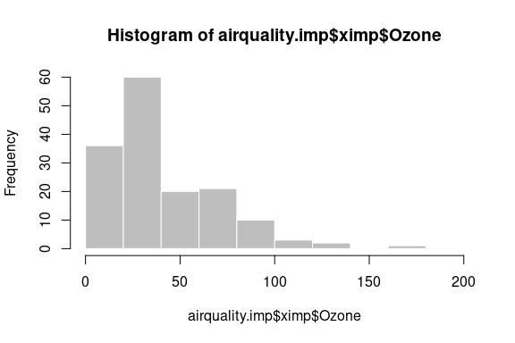

```r
hist(airquality.imp$ximp$Ozone, col = "grey", border = "white", xlim=c(0,200) )
```

## Bibliografía y enlaces

- https://www.ncbi.nlm.nih.gov/books/NBK493614/
- https://www.ncbi.nlm.nih.gov/pmc/articles/PMC3074241/
- https://data.library.virginia.edu/getting-started-with-multiple-imputation-in-r/
- https://cran.r-project.org/web/packages/mice/mice.pdf
- https://cran.r-project.org/web/packages/finalfit/vignettes/missing.html
- https://cran.r-project.org/web/packages/missForest/missForest.pdf
- https://cran.r-project.org/web/packages/missForest/vignettes/missForest_1.5.pdf
- https://cran.r-project.org/web/packages/Amelia/Amelia.pdf
- https://cran.r-project.org/web/packages/Amelia/vignettes/using-amelia.html
- https://cran.r-project.org/web/packages/Amelia/vignettes/ameliaview.html
- https://cran.r-project.org/web/packages/dplyr/dplyr.pdf
- https://cran.r-project.org/web/packages/finalfit/finalfit.pdf